# DATA607 HW1 Loading Data Into A Data Frame

# Introduction

This article is about what police misconduct settlement data, or lack thereof, can tell us about how police departments are changing for better or worse our current era of increasing calls for police reform. The article focuses heavily on the fact that the data on settlements for police misconduct is difficult to draw conclusions from due to the lack of standardization between departments, lack of transparency, and lack of data in some cases.

[Cities Spend Millions On Police Misconduct Every Year. Here’s Why It’s So Difficult to Hold Departments Accountable.](https://fivethirtyeight.com/features/police-misconduct-costs-cities-millions-every-year-but-thats-where-the-accountability-ends/)

# Analysis

## Load the libraries

I am loading two libraries for this project. The `dplyr` library to help with manipulating the dataframe and the `ggplot2` library for plotting the data.

install.packages(“dplyr”) install.packages(“ggplot2”)

```r
library("dplyr")
```

```r
library("ggplot2")
```

## Load the data

The data set I chose was the Chicago, IL data set. I chose this data set because it had a large amount of rows which I believe would make for more interesting analysis. The data set contains 24 columns and 1515 records. The data can be found in the same directory as this file as `chicago_edited.csv`

```r
chicagoMisconductPayouts <- read.csv(file = 'chicago_edited.csv')
head(chicagoMisconductPayouts)
```

```
##   calendar_year    city state incident_date incident_year filed_date filed_year
## 1          2019 Chicago    IL            NA            NA         NA         NA
## 2          2018 Chicago    IL            NA            NA         NA         NA
## 3          2019 Chicago    IL            NA            NA         NA         NA
## 4          2010 Chicago    IL            NA            NA         NA         NA
## 5          2010 Chicago    IL            NA            NA         NA         NA
## 6          2010 Chicago    IL            NA            NA         NA         NA
##   closed_date amount_awarded other_expenses collection total_incurred
## 1  2019-01-29         160000             NA         NA             NA
## 2  2018-10-02         100000             NA         NA             NA
## 3  2019-05-30          70000             NA         NA             NA
## 4  2010-09-24          60000             NA         NA             NA
## 5  2010-03-18          99000             NA         NA             NA
## 6  2010-03-31          22500             NA         NA             NA
##                                        case_outcome docket_number claim_number
```

[output cut: 34 more lines]

```r
nrow(chicagoMisconductPayouts)
```

```
## [1] 1515
```

## Subset the data

I subsetted the data down to just two columns. The year that the misconduct settlement was awarded and the dollar amount awarded. Those two values are the the most important variables in this data set.

```r
payoutsWithYear <- subset(chicagoMisconductPayouts, select = c("calendar_year", "amount_awarded"))
head(payoutsWithYear)
```

```
##   calendar_year amount_awarded
## 1          2019         160000
## 2          2018         100000
## 3          2019          70000
## 4          2010          60000
## 5          2010          99000
## 6          2010          22500
```

## Aggregate the data

I then grouped each row by the calendar year and summarized the data by taking the mean of the payouts for each year, summed the payouts per year, and counted the amount of settlements per year.

```r
summary <- payoutsWithYear %>%
  group_by(calendar_year) %>%
  summarise(Average_Amount_Rewarded = mean(amount_awarded),Total_Amount_Rewarded = sum(amount_awarded), Number_Of_Settlements = n())
summary
```

```
## # A tibble: 10 × 4
##    calendar_year Average_Amount_Rewarded Total_Amount_Rewarded Number_Of_Settle…
##            <int>                   <dbl>                 <dbl>             <int>
##  1          2010                 305778.             24462226.                80
##  2          2011                 203483.             22790143.               112
##  3          2012                 390242.             60487581.               155
##  4          2013                 506050.             92607082.               183
##  5          2014                 186598.             29669161.               159
##  6          2015                 150062.             22509331.               150
##  7          2016                 160494.             31296263.               195
##  8          2017                 534597.             94623599.               177
##  9          2018                 314646.             56950918.               181
## 10          2019                 261709.             32190160.               123
```

## Graph the data

I graphed the total settlements in dollars per year as I thought it might show a trend in the dollar amount of settlements increasing over time. What I found was there were two peak years 2013 and 2017 with much lower amounts in the remaining years. Some other interesting insights are that 2017 appears to have fewer payouts than both 2016 and 2018 indicating that they may have been a uncharacteristically large payout in the year of 2017 causing it to be higher than other years.

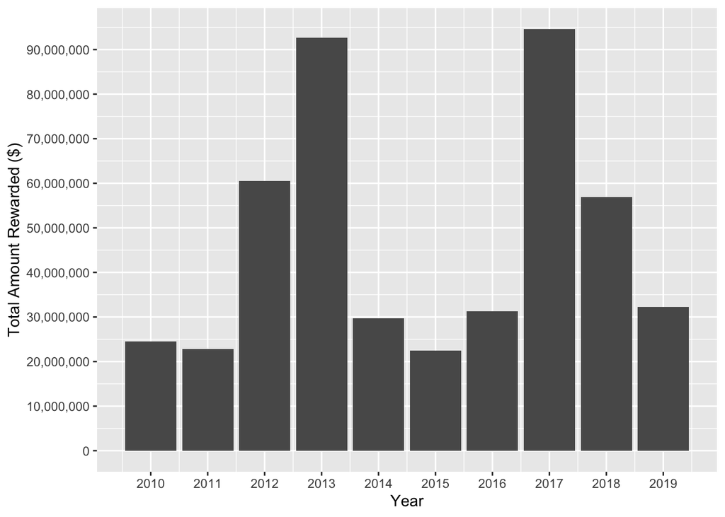

```r
ggplot(data=summary, aes(x=calendar_year, y=Total_Amount_Rewarded)) +
  geom_bar(stat = "identity") +
    scale_y_continuous(
  labels = scales::comma_format(big.mark = ','),breaks = seq(0, floor(max(summary$Total_Amount_Rewarded)), by = 10000000)) +
    scale_x_continuous(breaks = seq(min(summary$calendar_year), max(summary$calendar_year), by = 1)) +
  ylab("Total Amount Rewarded ($)") +
  xlab("Year")
```

# Conclusions

Something that the article brought up that I would be interested in pursing further is comparing the settlements for more conservative cities versus more liberal cities. The idea being conservative areas of the country may be more apt to side with the police and less likely to award large settlements.

If I were to do that I would plot the data from cities with different political leanings and compare the data to see if it supported the hypothesis. This might require additional data to determine what areas have what political affiliations.